# Writing Manuscripts with Quarto: A Workshop!

Author

Affiliation

Luke Hearon

The Ohio State University

# Introduction

Abuse of caffeine is estimated to increase scientific productivity by roughly 130% in graduate students (Lee et al. 2009, Hearon et al. 2025), but may have detrimental effects on sleep (Kerpershoek et al. 2018). However, we hypothesize that the first coffee after a night of no sleep absolutely *slaps*. To confirm this hypothesis, we conducted a survey-based study on graduate students at The Ohio State University.

# Methods

We sourced ground coffee from three sources: Kroger Private Selection, Stauf’s Coffee Roasters, and author LH’s personal supply. Coffee was additionally collected from an unnamed national entomological society’s annual conference in accordance with methods described by Mouton et al. (2016). In brief, the authors donned hi-viz vests, selected an urn of coffee in a randomized block design, and made a run for the door. 8 of 16 urns were successfully collected in this manner. Gas chromatography–Tandem mass spectrometry analysis (GC-MS/MS) revealed no compounds known to science in the Conference coffee, but it was assumed to qualify as coffee under a colloquial definition.

Graduate students were lured recruited to the study via the advertisement of free caffeine. Students were given a questionnaire regarding their graduate work and asked to report the hours of sleep they got the night before the study. A thermos of freshly brewed coffee was given to each student in a randomized manner to drink across the course of the workday. After the workday, students were asked to score their enjoyment of the coffee on a scale of 1–10. Students who stated a preference for yerba matte over coffee were ejected from the study and from polite society.

# Results

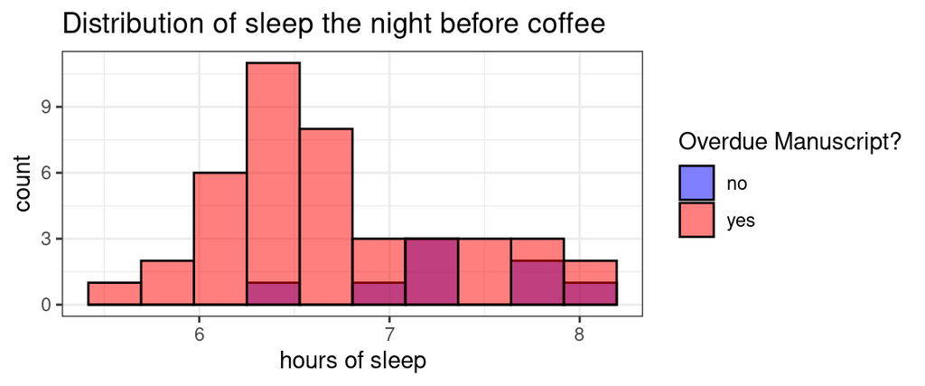

Figure 1. Distribution of sleep reported the night before the experiment.

In total 50 students were interviewed. Interviewees averaged 6.8±0.66 hours of sleep the night before the study, as shown in Fig. 1. Being overdue on a manuscript draft deadline set by the advisor decreased sleep by -0.65 hours on average (F = 7.5, *p* < 0.01). 84% of students had overdue manuscripts.

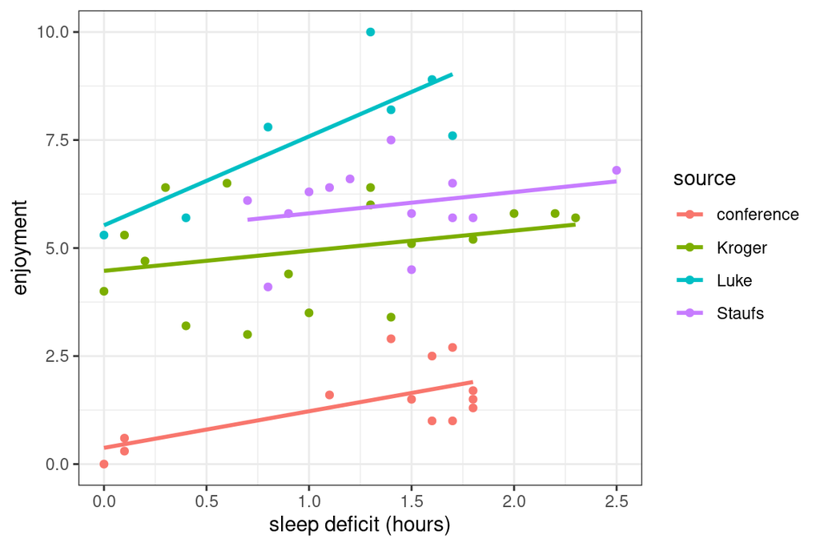

Figure 2. Effects of sleep and source on reported enjoyment of coffee among graduate students. Sleep deficit is calculated as the difference between the number of hours of reported sleep and 8 hours.

Graduate students were found to drink fairly crappy coffee, with an average enjoyment score of 4.7±2.4 out of 10 (see Fig. 2). Luke’s coffee outclassed all others, with a 95% confidence interval of (6.44, 7.94).

# Conflict of Interest

The authors declare that they were highly interested in proving Luke’s coffee to be superior to all others, but strenuously deny that this affected the results of the study. Author LH was reimbursed at a rate of $15 per cup of coffee furnished; this value was initially found to be inappropriately high by the IRB, but the judgement was reversed after author LH provided honey lattes to the IRB.

## Works Cited

Hearon LH, Johnson LHP, Ahn D. 2025. Spending 2h per workday making espresso is actually a good use of time, all considered. Journal of Graduate Procrastination. 1(6). https://doi.org/10.1111/1365-2664.14630

Kerpershoek ML, Antypa N, Van Den Berg JF. 2018. Evening use of caffeine moderates the relationship between caffeine consumption and subjective sleep quality in students. Journal of Sleep Research. 27(5):e12670. https://doi.org/10.1111/jsr.12670

Lee K-H, Human G, Fourie J, et al. 2009. Medical students’ use of caffeine for ‘academic purposes’ and their knowledge of its benefits, side-effects and withdrawal symptoms. South African Family Practice. 51(4):322–327. https://doi.org/10.1080/20786204.2009.10873872

Mouton F, Leenen L, Venter HS. 2016. Social engineering attack examples, templates and scenarios. Computers & Security. 59:186–209. https://doi.org/10.1016/j.cose.2016.03.004